# Intro to Statistics

Variables, Samples, Population, Data

Bogdan G. Popescu

bogdan.popescu@johncabot.edu

John Cabot University

## Variables

How are two or more variables related?

- An **independent variable** is thought to influence or cause variation in another variable
- A **dependent variable** depends upon or is caused by variation in the independent variable

**Examples:**  
Independent Variable → Dependent Variable

Education → Income

## Associations

Two variables are **associated** if knowing the value of one of them will help to predict the value of the other.

**Example:**  
Life Expectancy and Urbanization

## Life Expectancy and Urbanization

**Life Expectancy**

- Indicator of countries’ overall health, physical well-being
- Of interest to many, including health researchers, economists, sociologists, anthropologists…

We will examine UN data on average life expectancy for 214 countries.

We want to know if urbanization has a positive or negative relationship on life expectancy.

## Life Expectancy and Urbanization

**The Data**

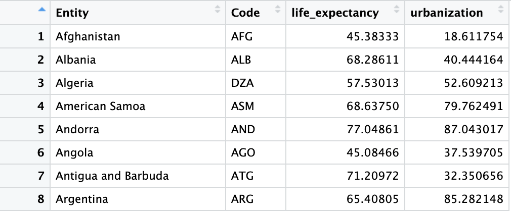

Life Expectancy vs Urbanization

- A row for each country
- Countries are subjects, cases, units, or elements in the data set
- Two columns for life expectancy and urbanization
- These are variables or characteristics varying among units

## Life Expectancy and Urbanization

- What explains variation in life expectancy?
- What characteristics do countries with longer life expectancy have in common?
- What characteristics do countries with shorter life expectancy have in common?
- Normally, we would be examining the relationship between different types of variables and life expectancy:
  - income
  - urbanization
  - education

## Correlates of Life Expectancy

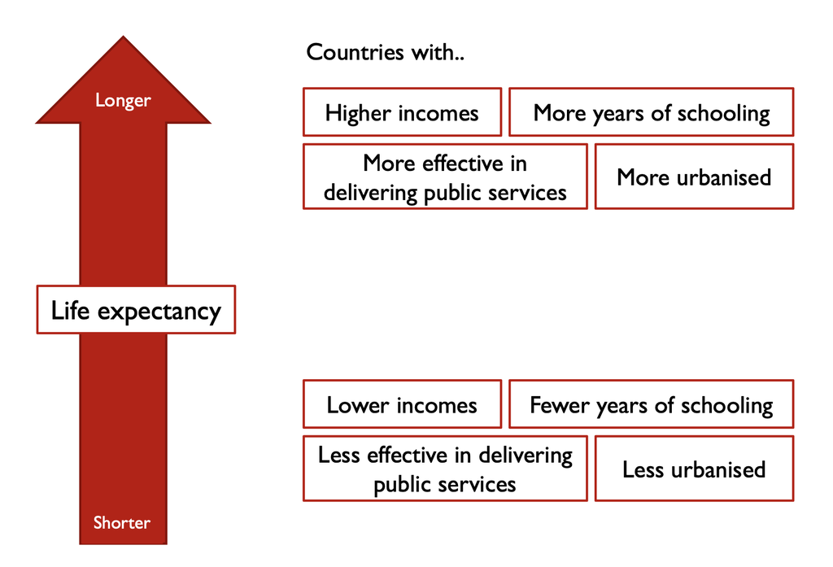

Correlates of Life Expectancy

## A scatterplot of life expectancy by urbanization

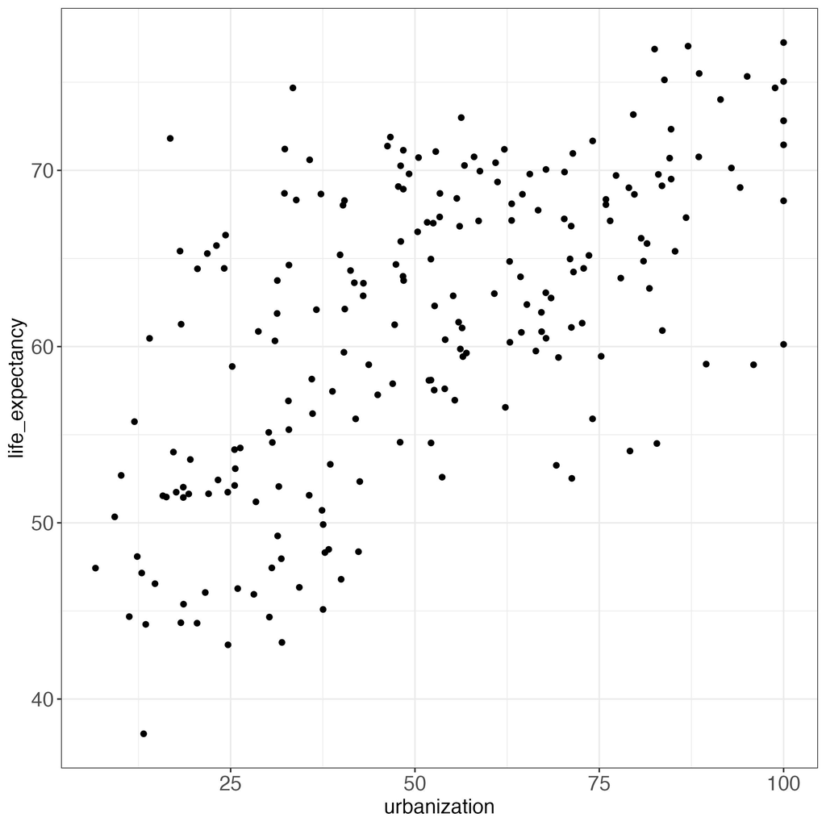

Scatterplot 1

## Associations vs. Causal Relationships

- If two variables are associated, knowing the value of one helps predict the value of the other
- In this example, we would predict:
  - A middle-income country would have a longer life expectancy than a low-income country
  - A country with more urbanization would have longer life expectancy than one with less

## Causal Relationships

A **causal relationship** entails three elements:

- The independent (X) and dependent variables (Y) covary
- The change in X precedes the change in Y
- The covariation between X and Y is not coincidental or spurious

Causal relationships can be stipulated in hypotheses.

## Hypotheses

Relationships between variables can be stated in hypotheses.

A **hypothesis** is an explicit statement about the relationship between phenomena that formalizes the researcher’s informed guess.

## Characteristics of Good Hypotheses

- Empirical statements that formulate educated guesses
- Logical reason to think data can confirm hypotheses
- Indicate direction of the relationship
- Terms must match testing methods
- Data should be feasible to obtain
- Must specify unit of analysis (individuals, orgs, states, etc.)

## Examples of Hypotheses

- People have political viewpoints similar to their parents.
- Democracies are more likely to engage in trade with one another.
- Authoritarian regimes are more likely to violate human rights.
- Countries where property rights are protected tend to have higher levels of development.

## Concepts

Definitions of concepts should be:

- clear
- accurate
- precise
- informative

Concepts should strike a balance between the specific and the abstract.

## Populations vs. Samples

**Population** – complete enumeration of some set of interest

To learn about the population, a sample is often studied

**Sampling** is the process of selecting a subset from the population

Sampling is used to estimate characteristics of the full population

Aim: Ensure sample is representative

Requirement: Know your population

Dominant approach: **probability sampling**

## Populations vs. Samples

**Representative sample** – If repeated, the sample’s features would match those of the population on average

Probability sampling reduces sample selection bias and ensures representativeness

## Data and Variables – Basics

**Categorical**

- **Binary**: e.g., 0 = unemployed, 1 = employed
- **Nominal**: Order does not matter (e.g., 0 = Green, 1 = Red, 3 = Blue)
- **Ordinal**: Order is meaningful (e.g., 0 = Poor, 1 = Fair, 2 = Good)

## Data and Variables – Basics

**Numerical**

- **Discrete**: e.g., number of individuals in a household
- **Continuous**: e.g., height, weight, wages

## Cross-Sectional Data

- Cross-sectional datasets have **one observation per unit**
- Data for one variable (attribute) measured in *N* countries is written as:

$$\{X_1, X_2, X_3, \dots, X_N\} = \{X_i\}_{i=1,\dots,N}$$

## Cross-Sectional Data

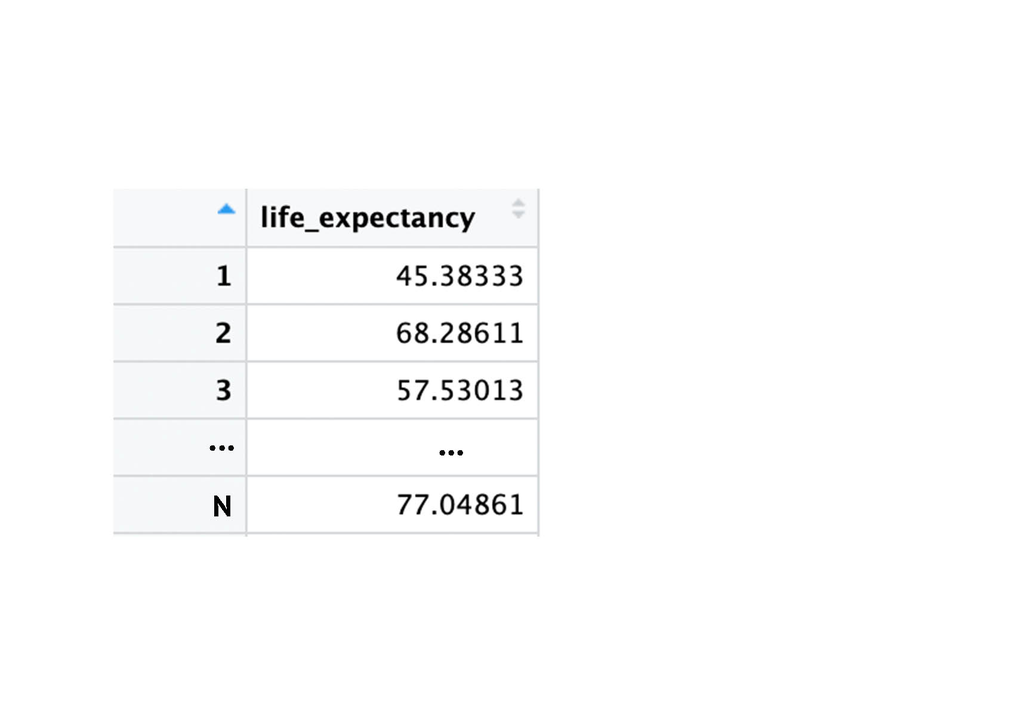

## Cross-Sectional Data

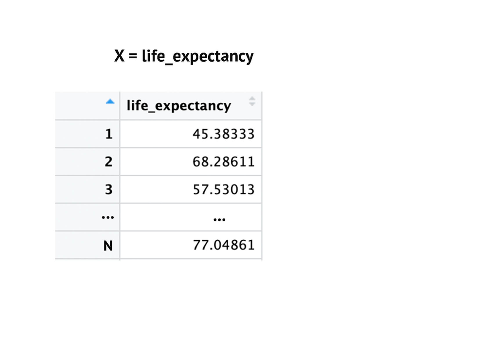

## Cross-Sectional Data

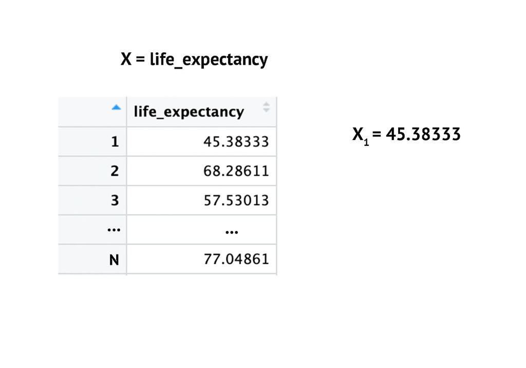

## Cross-Sectional Data

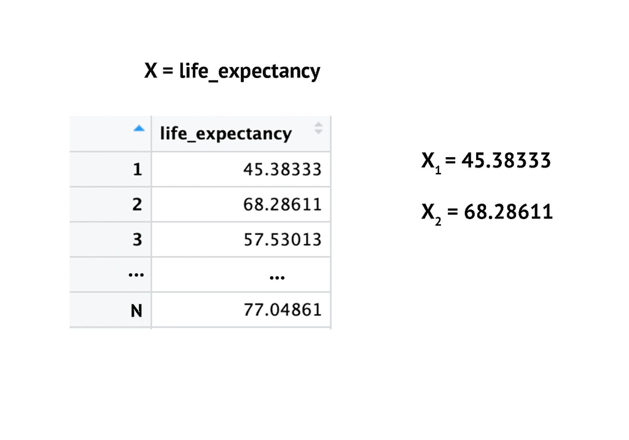

## Cross-Sectional Data

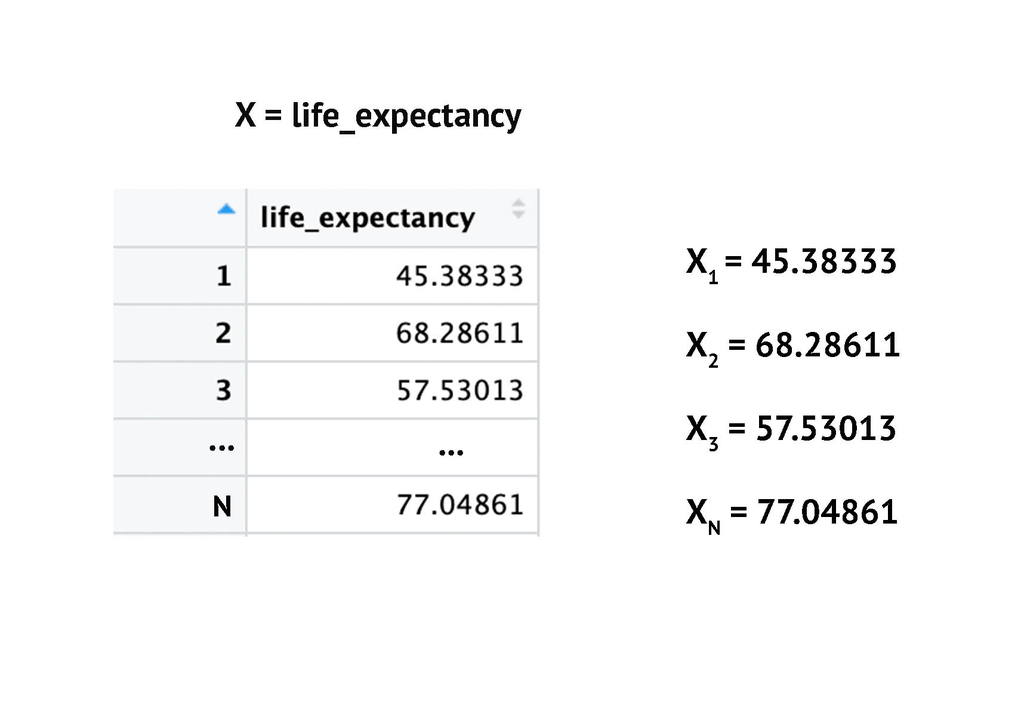

## Cross-Sectional Data

- Cross-sectional datasets have **one observation per unit**
- Example values for one variable (e.g., life expectancy):

$$\{X_1, X_2, X_3, \dots, X_N\} = \{X_i\}_{i=1,\dots,N}$$

$$\{45.38333, 68.28611, 57.53013, \dots, 77.04861\} = \{X_i\}_{i=1,\dots,N}$$

## Cross-Sectional Data

- If we measure **two attributes**, we can represent them as a point in 2D space
- A single data point is a vector in two dimensions

Example:  
- Life expectancy = 59.75  
- Level of urbanization = 66.4

Then the data point is:

## Cross-Sectional Data

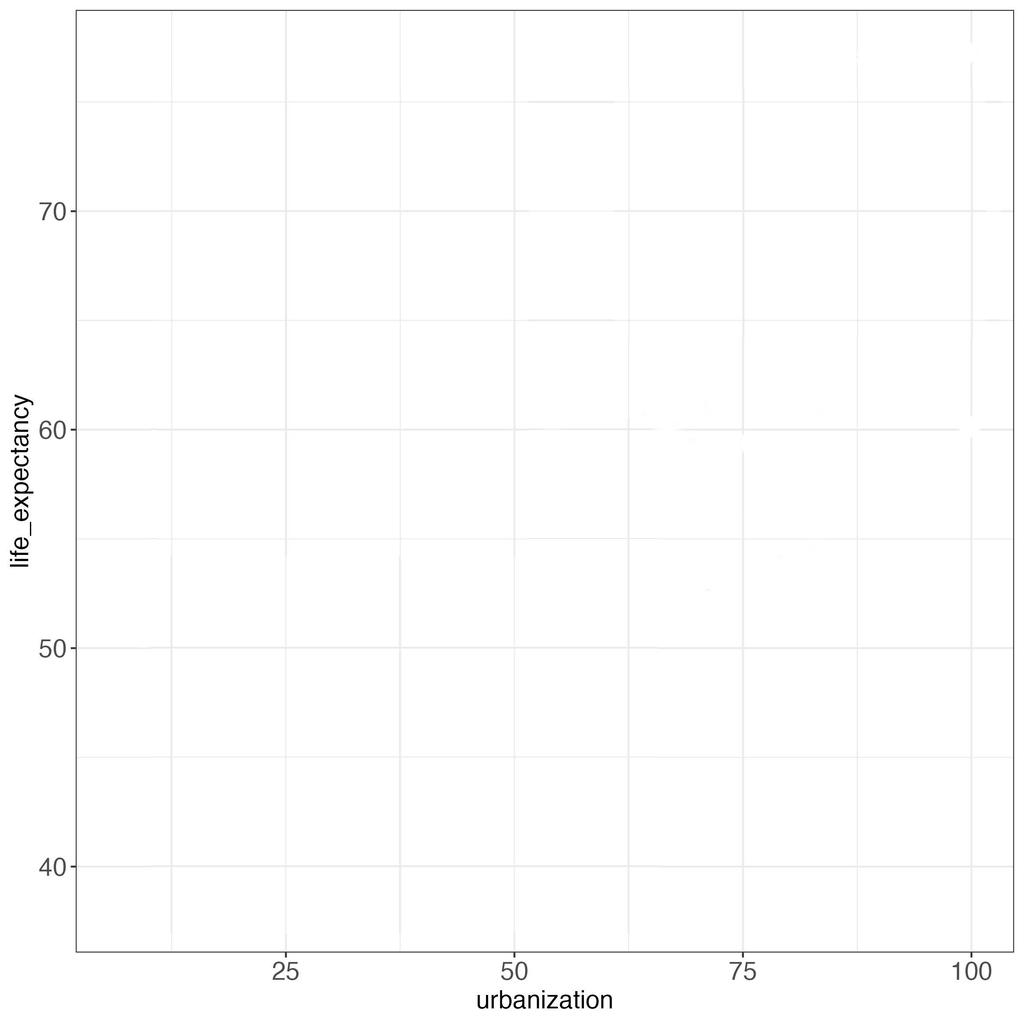

## Cross-Sectional Data

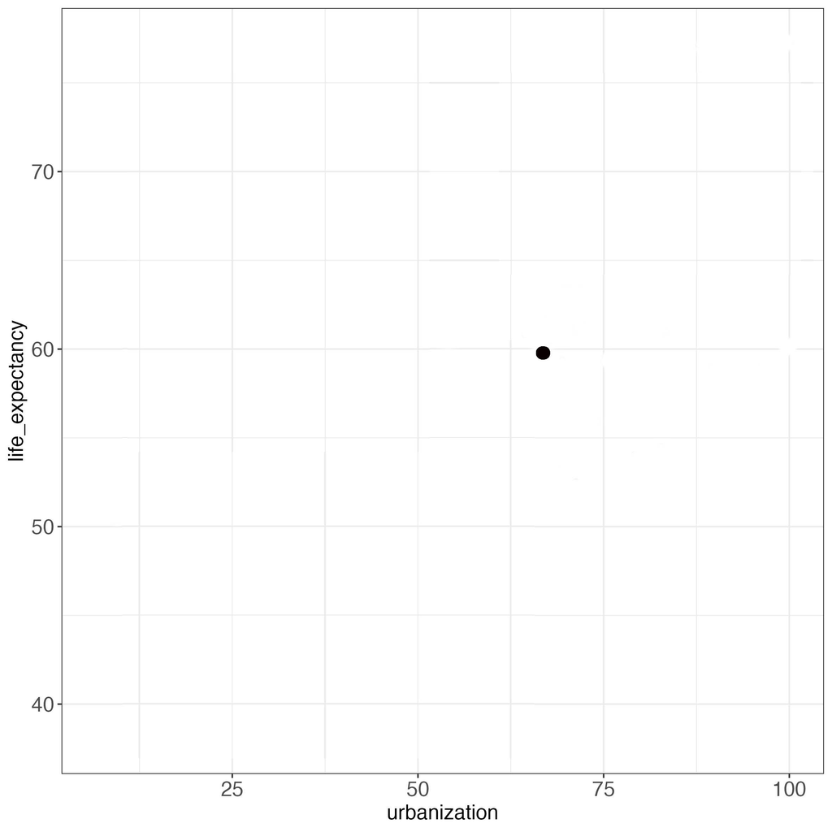

## Cross-Sectional Data

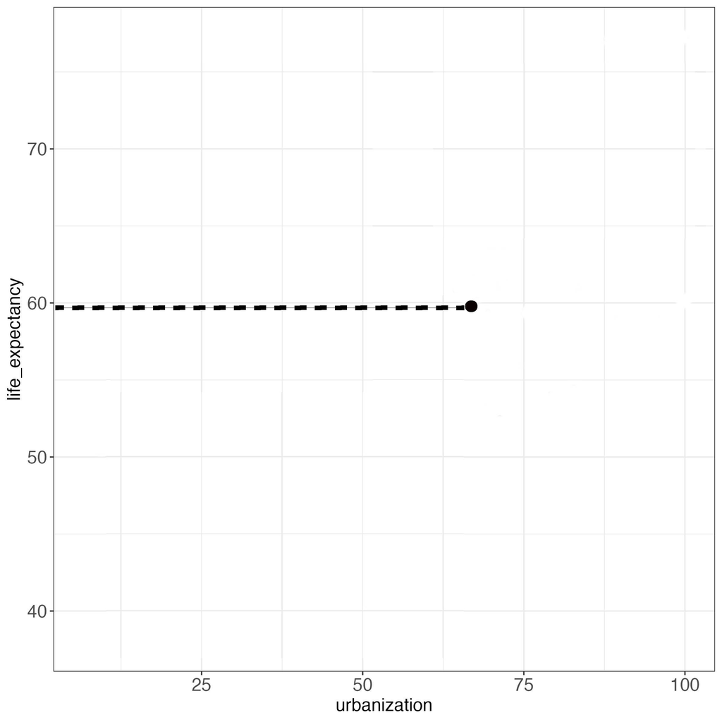

## Cross-Sectional Data

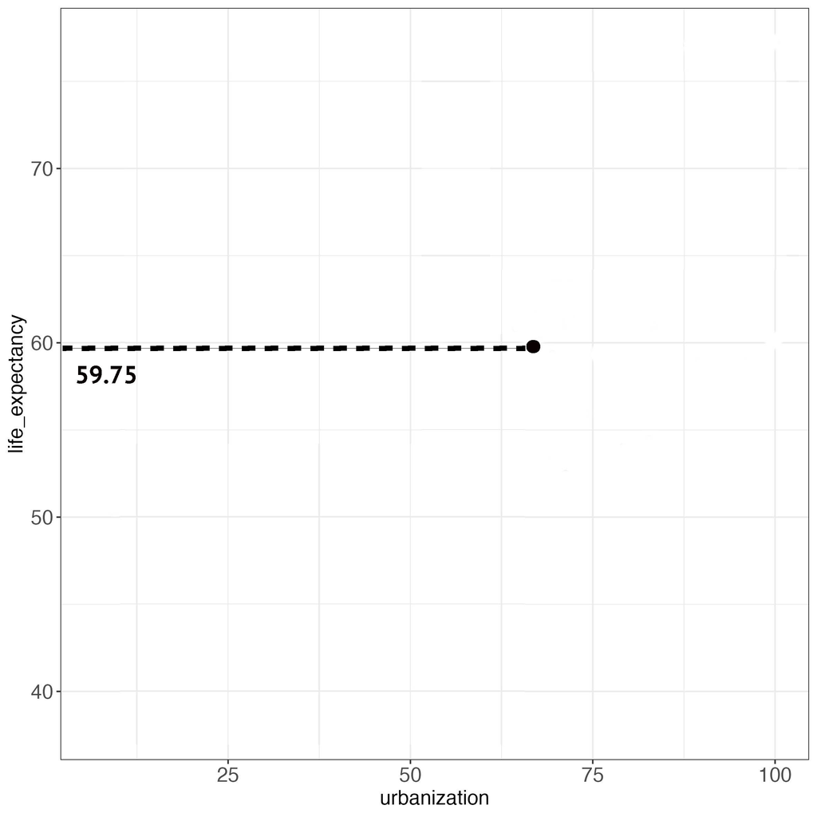

## Cross-Sectional Data

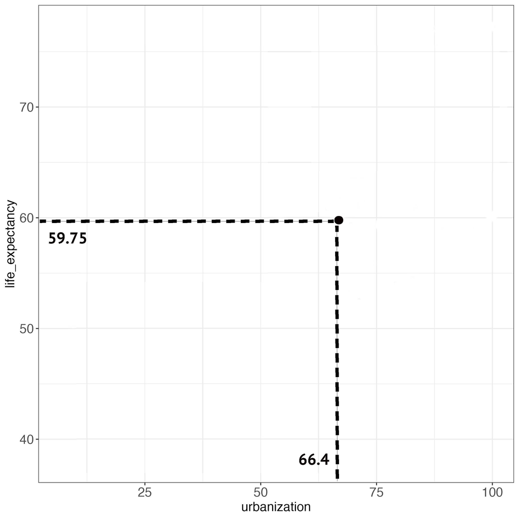

## Cross-Sectional Data

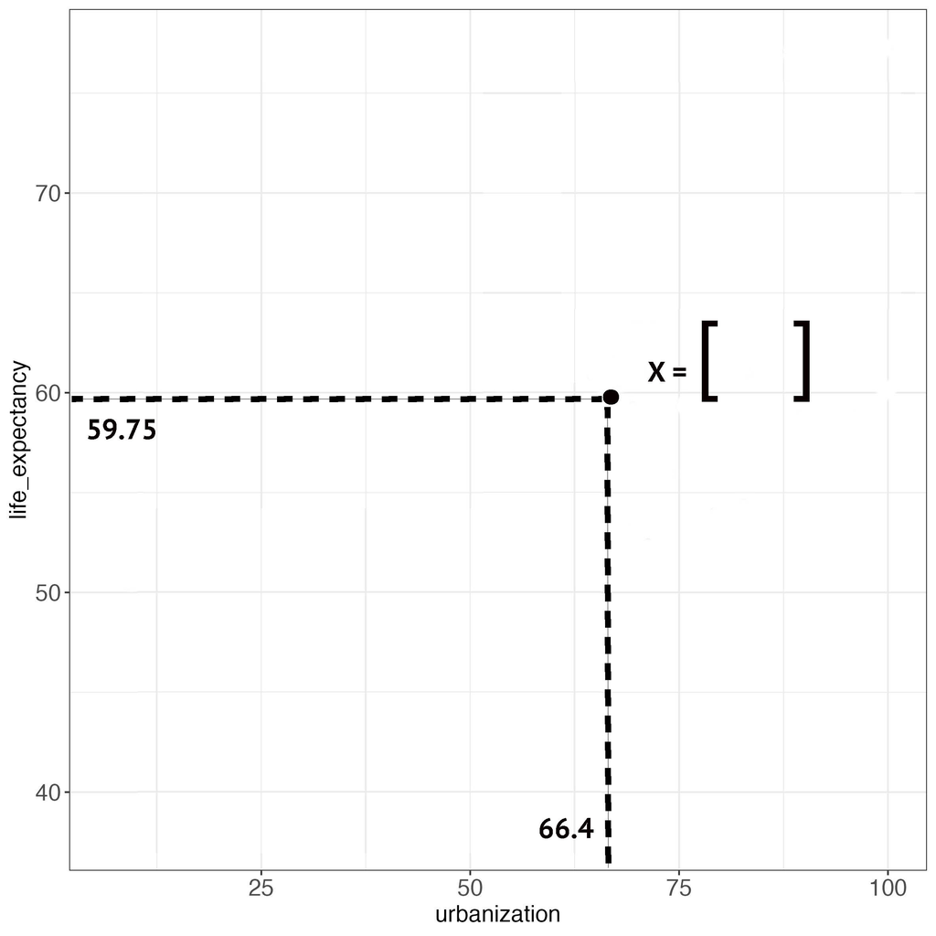

## Cross-Sectional Data

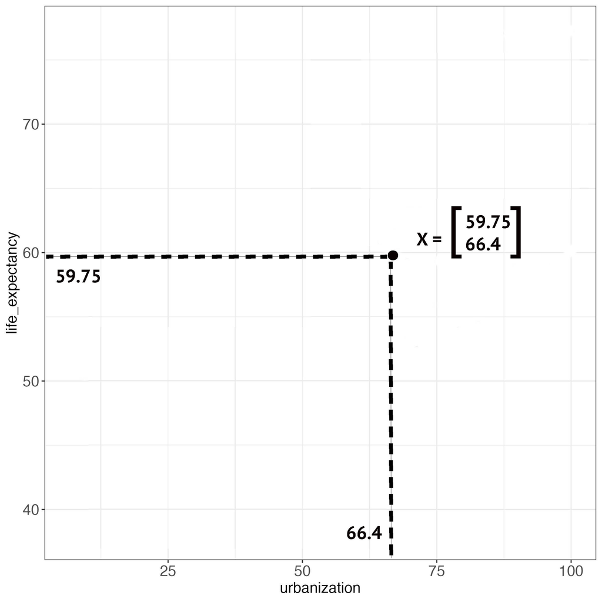

## Cross-Sectional Data

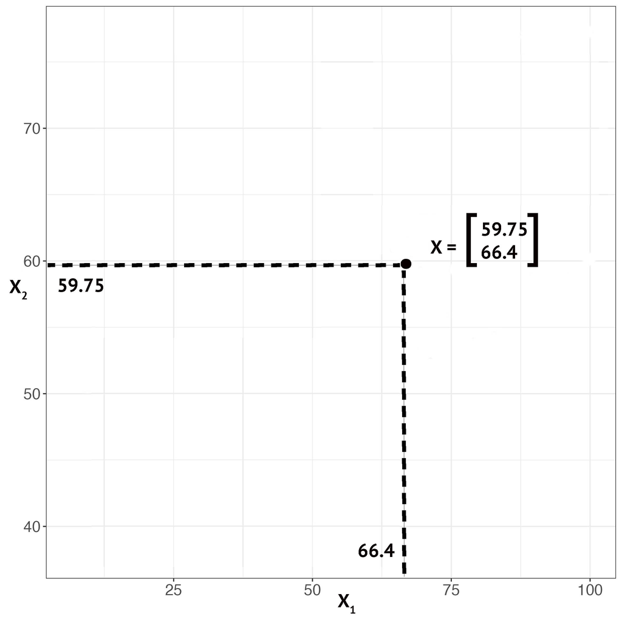

## Evaluation of Empirical Propositions

Social scientists use statistical analyses to verify theories driven by carefully thought-out hypotheses.  
Hypotheses are **falsifiable claims** about the world.  
Hypotheses connect **dependent variables** to **independent variables**.  
- **Dependent variables**: outcomes or things we want to explain  
- **Independent variables**: factors that help explain the dependent variable

## Example

**Hypothesis**:  
An increase in **X** (independent variable) leads to an increase in **Y** (dependent variable).  
**Democratization Hypothesis**:  
More **economic development** is associated with **higher levels of democracy**.  
To test this, we collect data on X and Y.  
**Units of analysis** are the entities where our theory applies (e.g., countries, individuals, firms).

## Datasets

When we collect the data, we input it into a *spreadsheet*, a tabular format.  
This becomes a **dataset**.

## A Dataset

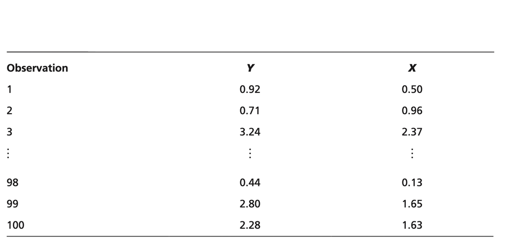

## A Dataset

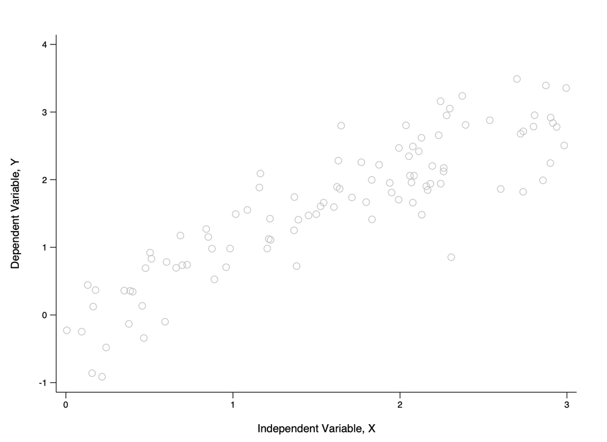

## A Dataset

In this example, there appears to be a **positive relationship** between X and Y.  
- Not all high-X observations have high Y  
- Not all low-X observations have low Y  
To evaluate the relationship, we fit a line that best approximates the pattern in the data.

## A Dataset

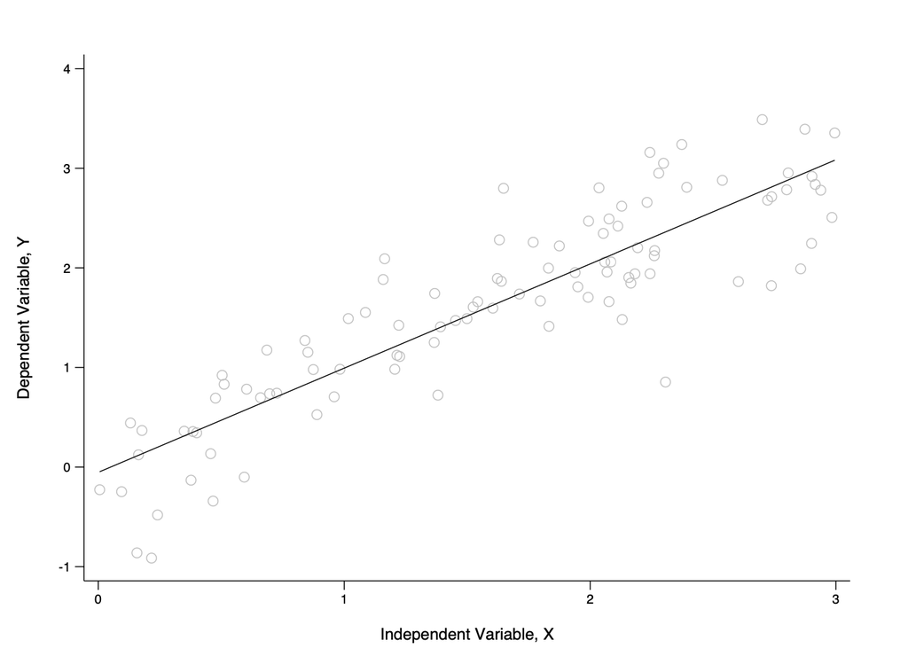

## Cross-Sectional Data

Each country’s data is a **point in a scatter plot**.  
If we measure three variables (e.g., life expectancy, urbanization, education),  
we get a **3D point cloud**:

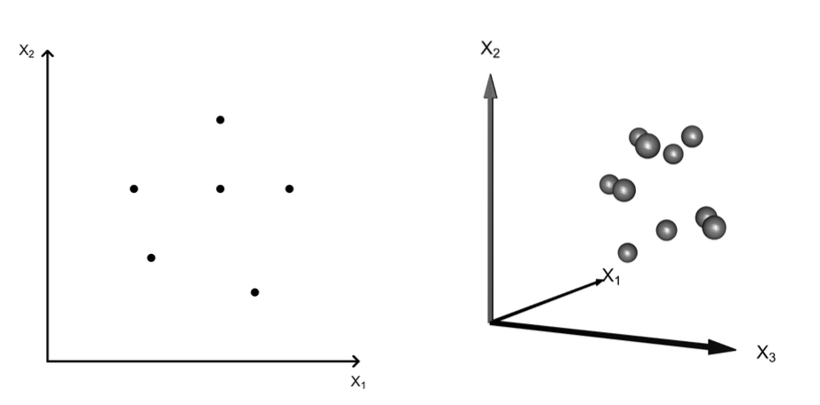

## Time-Series Data

- A time series of length T is written as:

$$\{X_1, X_2, X_3, \dots, X_T\} = \{X_t\}_{t=1,\dots,T}$$

- A time series is a sequence of data points indexed in **time order**
- It has a **natural temporal ordering**
- Time is the **second attribute**

## Time-Series Data

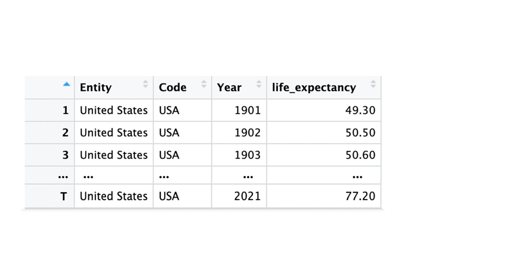

## Time-Series Data

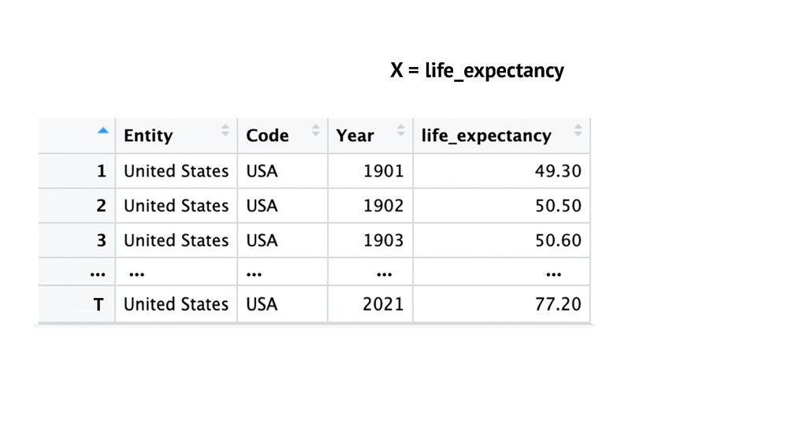

## Time-Series Data

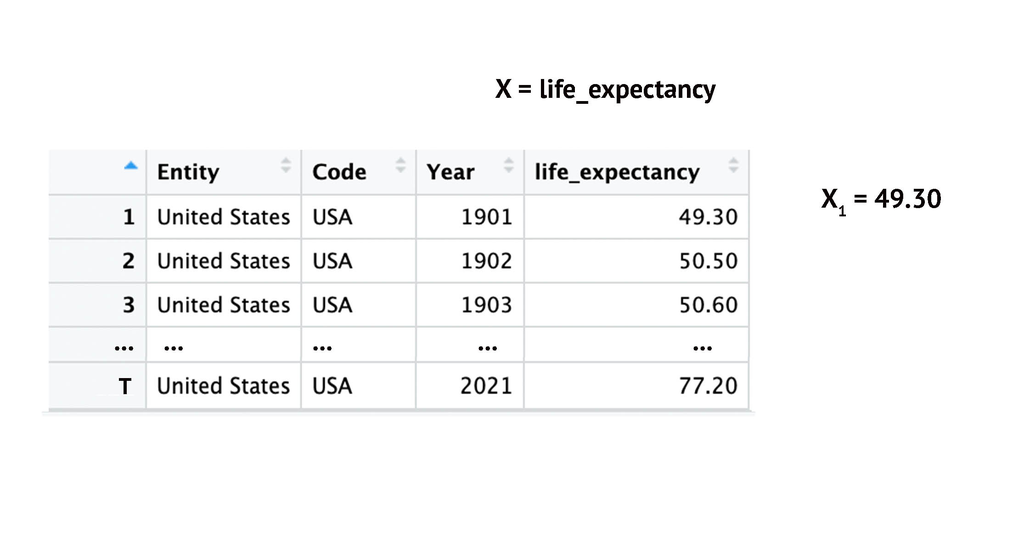

## Time-Series Data

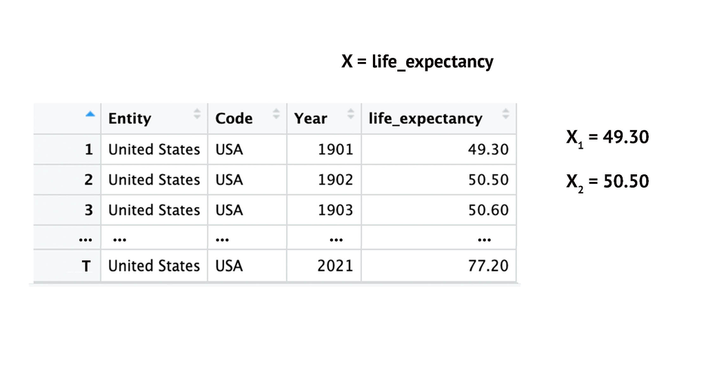

## Time-Series Data

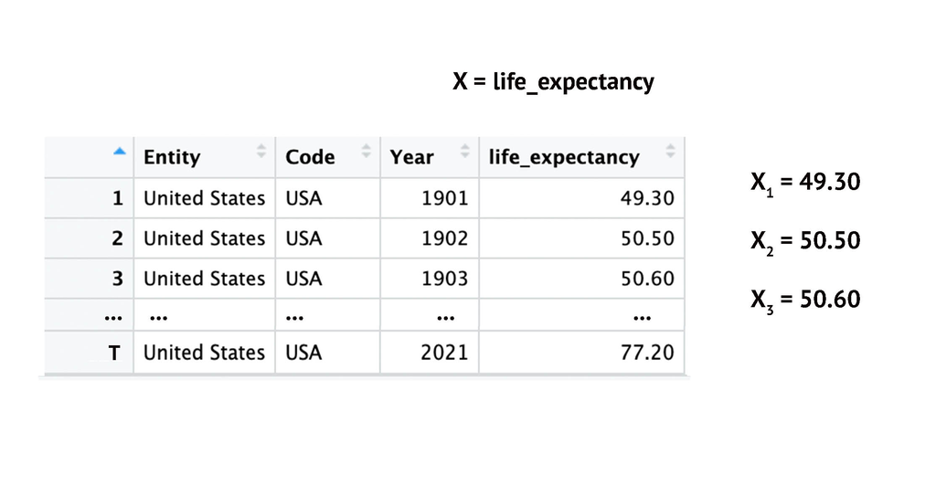

## Time-Series Data

[figure not shown]

## Time-Series Data

[figure not shown]

## Time-Series Data vs. Cross-Section

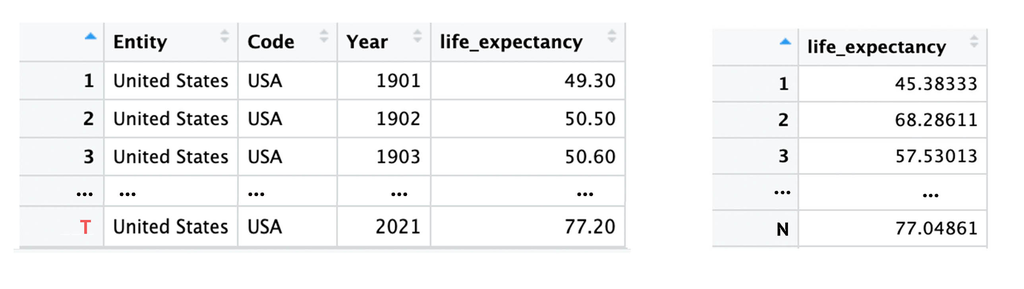

## Time-Series Data vs. Cross-Section

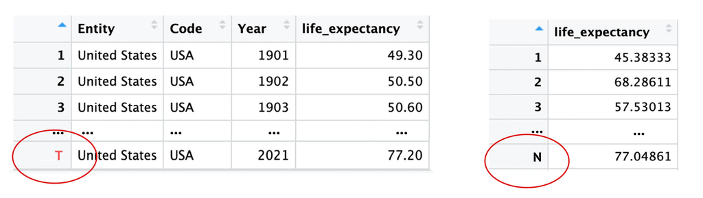

## Time-Series Data

This is depicted as a **2D scatter**.  
Time is one variable, and the value of interest is another.  
So, each point in the time series is a **pair: (time, value)**.

## Time-Series Data

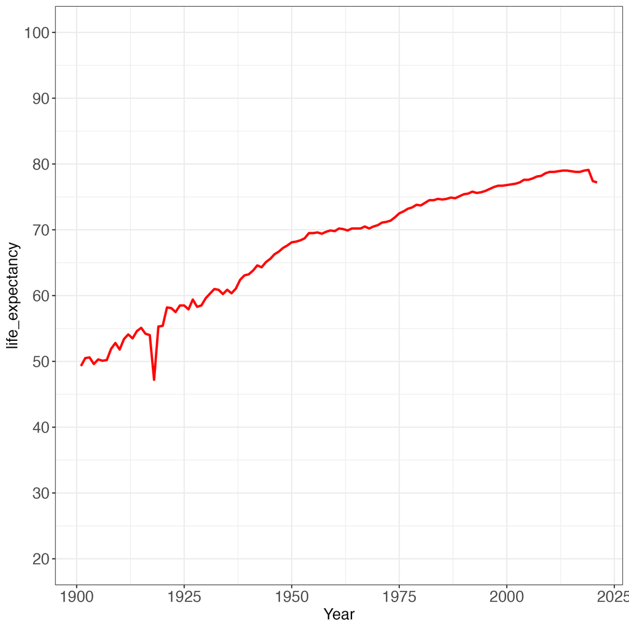

## Time-Series and Cross-Section Data

**Balanced Panel** = Every unit is observed in every time period. No missing time points for any unit.

## Time-Series and Cross-Section Data

**Unbalanced Panel** = Some units are missing observations for some time periods.

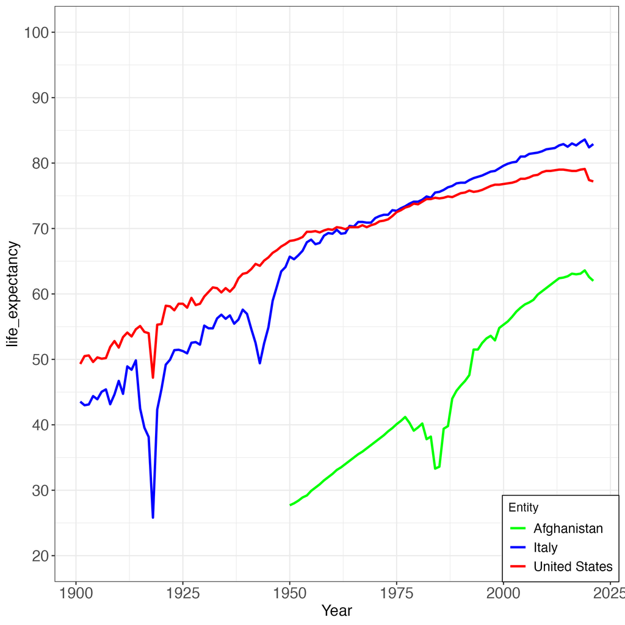

## Time-Series and Cross-Section Data

**Balanced Panel** = Every unit is observed in every time period. No missing time points for any unit.

## Time-Series and Cross-Section Data

**Unbalanced Panel** = Some units are missing observations for some time periods.

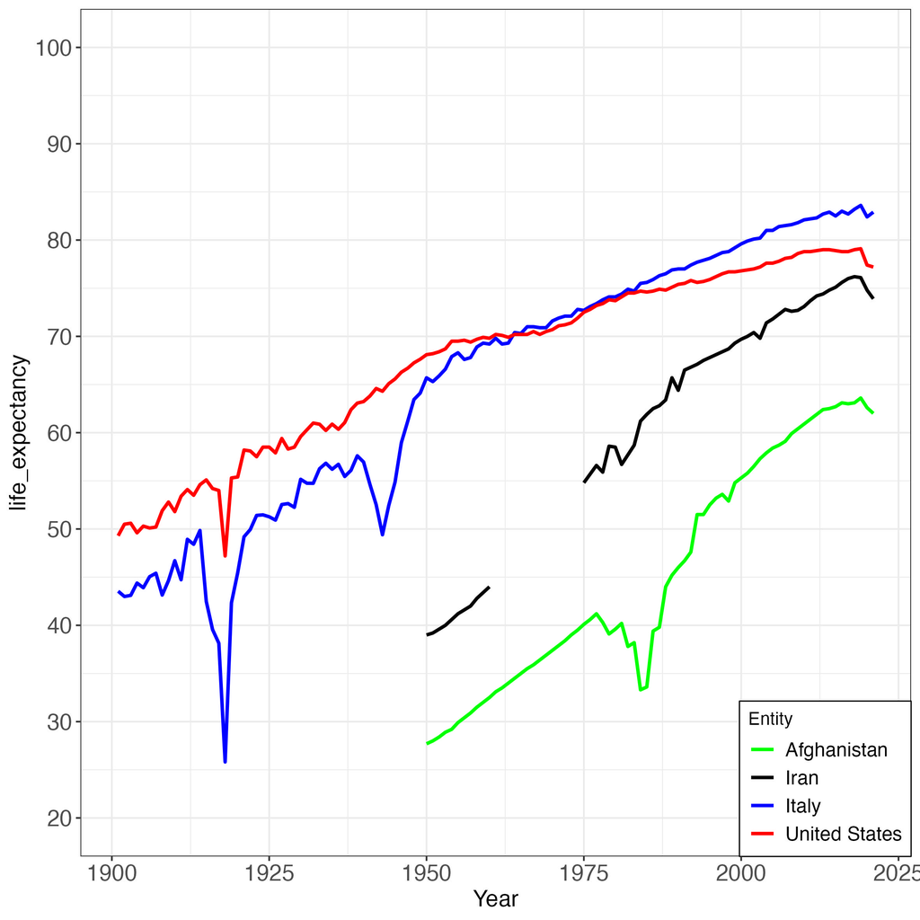

## Conclusion

- Measurement quality depends on **accuracy** and **precision**
- **Reliability**: can we replicate results?
- **Validity**: does the measure reflect the concept?
- Variables can be **categorical** or **numerical**
- Data can be **cross-sectional**, **time-series**, or both (**panel data**)
- **Panel data** can be **balanced** or **unbalanced**